# Web scrapping

Autor

Diabb Zegpi

[figure not shown]

Scrapper del augurio, quiero ver más allá de lo evidente

## Introducción

De acuerdo con el popular sitio web de programación [geeksforgeeks.org](https://www.geeksforgeeks.org/what-is-web-scraping-and-how-to-use-it/), *“web scrapping es un método automático para obtener grandes cantidades de datos de sitios web”.* Gran parte de estos datos son no-estructurados, en formato HTML, los que después son convertidos en datos estructurados en una hoja de cálculo o en una base de datos, desde donde pueden ser consultados por múltiples aplicaciones.

El web scrapping es llevado a cabo secuencialmente por dos algoritmos, el **crawler** y el **scrapper**. El crawler es un algoritmo que navega un sitio web en búsqueda de patrones particulares, siendo los más comunes los selectores CSS y el path de XML. Por otra parte, el scrapper es una herramienta que extrae los datos de la web, de acuerdo con los resultados encontrados por el crawler. Las herramientas modernas de web scrapping incorporan ambos componentes, crawler y scrapper, en frameworks integrales diseñados para armonizar con el workflow de data science.

Este tutorial cubre web scrapping, programado con `python` y con `R`.

Antes de comenzar con el scrapping, realizaremos una introducción a HTML y CSS.

[figure not shown]

Logos de HTML versión 5 y CSS versión 3

## HTML

HyperText Markup Language (HTML) es el lenguaje en que son creados los sitios web, aunque no es un lenguaje de programación, como python. Es un lenguaje de marcado que le dice al navegador cómo mostrar contenido. HTML consiste en elementos denominados **tags**. El más básico de los tags es `<html>`. Este tag le dice al servidor que todo lo que está “rodeado por él” es HTML. Podemos crear un documento HTML con la siguiente instrucción:

```html
<html>
  contenido del sitio web...
</html>
```

Inmediatamente después del tag html, le prosiguen `<head>` y `<body>`. El contenido principal del sitio web está en body; el tag head contiene metadatos sobre el sitio web, que comúnmente no son útiles para el web scrapper, como el título de la web y llamadas a archivos que dan estilo al sitio.

```html
<html>
  <head>
    metadata
  </head>
  <body>
    contenidos
  </body>
</html>
```

A continuación, añadiremos más tags para mostrar el contenido de nuestro sitio web.

```html
<html>
  <head></head>

  <body>
    <p>Este es un párrafo.</p>
    <div>
      Este es un contenedor de bloque.
      <span>Este es un contenedor en línea con letras <i>itálicas</i> y letras en <b>negrita</b>
    </div>
  </body>
</html>
```

Estos son algunos de los tags más usados. Para una lista completa de todos los tags que existen, click [aquí](https://developer.mozilla.org/en-US/docs/Web/HTML/Element).

## CSS

Cascading Style Sheets (CSS) es un lenguaje de estilo para sitios HTML. Si bien HTML otorga estructura al sitio web, CSS entrega el estilo (colores, fuentes, tamaños, animaciones, efectos, etc.). En web scrapping, utilizaremos los selectores CSS para escoger los elementos que deseamos obtener. Por ejemplo:

#### HTML

```html
<div></div>
<div class="contenedor">
  <div></div>
</div>
<div id="tercer-contenedor"></div>
```

#### CSS

```css
div {
  text-align: center;
}

.contenedor {
  color: #3c9add;
}

#tercer-contenedor {
  margin-top: 20px
}
```

Podremos seleccionar todos los div de un sitio web con el selector `div`, todos los elementos con clase contenedor con `.contenedor`, o todos los elementos con id “tercer-contenedor”, con el selector `#tercer-contenedor`. Además, existen maneras de combinar estos selectores, por ejemplo, para seleccionar todos los div con clase contenedor, podemos escribir `div.contenedor`. También podemos seleccionar elementos que descienden de otros, de la manera `div.contenedor div`, que seleccionaría todos los div que descienden de un div con clase contenedor.

El sitio [w3schools.com](https://www.w3schools.com/cssref/css_selectors.asp) ofrece una guía completa de selectores CSS. ¡Ya estamos listos para hacer web scrapping!

## Web scrapping con `python`

En python existen al menos 3 grandes paquetes de web scrapping: [Selenium](https://selenium-python.readthedocs.io/) (automatización de browser), [Scrapy](https://scrapy.org/) (framework de web scrapping) y [BeautifulSoup](https://www.crummy.com/software/BeautifulSoup/bs4/doc/). En este tutorial cubriremos el último. Dividiremos el tutorial en 5 pasos.

### Paso 1: instalar paquetes

Primero, instalamos `beautifulsoup4` con pip.

```bash
pip install beautifulsoup4
```

Debido a que beautifulsoup no realiza el GET request al sitio web, también requeriremos el paquete `requests` .

```bash
pip install requests
```

### Paso 2: escoger un sitio web

Utilizaremos el sitio web del Servicio de Impuestos Internos, concretamente, el que muestra el valor de la UF en pesos chilenos. [Aquí hay un link](https://www.sii.cl/valores_y_fechas/uf/uf2022.htm) para ir al sitio web. El objetivo es descargar el precio de la UF para todos los días de septiembre de 2022.

[figure not shown]

Valor de la UF en septiembre de 2022, Servicio de Impuestos Internos.

### Paso 3: descargar el sitio web

Una vez seleccionado el sitio web, necesitamos descargarlo en memoria. Esto se consigue haciendo un GET request mediante el paquete `requests`.

```python
import requests
url = 'https://www.sii.cl/valores_y_fechas/uf/uf2022.htm'
pagina = requests.get(url)
```

Podemos imprimir el contenido de la página con el atributo `content` (no lo imprimiremos, porque el output es muy largo).

```python
pagina.content
```

A continuación, utilizaremos `BeautifulSoup` para obtener el texto del HTML, llamando a la clase BeautifulSoup e instanciándola.

```python
from bs4 import BeautifulSoup
soup = BeautifulSoup(pagina.content, 'html.parser')
```

Imprimir la estructura del HTML con `soup.prettify()` no es necesario, pero puede ayudar a generarnos una idea de cómo luce el sitio web. Ya estamos listos para extraer datos.

### Paso 4: usar los selectores CSS

Usaremos el método `select()` para seleccionar (con selectores CSS) todos los tags `td` (table data) que son descendientes de elementos con id “mes_septiembre”. El resultado es un objeto de clase `bs4.element.ResultSet`, que contiene todas las coincidencias de la búsqueda. Cada coincidencia tiene el atributo `get_text()`, mediante el que podemos extraer el texto encerrado por los tags de HTML.

Ahora, iteremos con *list comprehension* para obtener el texto de cada resultado de beautiful soup.

```python
table_data = soup.select('#mes_septiembre td')
table_data = [data.get_text() for data in table_data]
table_data
```

```
['33.851,69', '34.000,39', '34.135,85', '33.866,87', '34.013,91', '34.149,42', '33.882,06', '34.027,44', '34.163,01', '33.897,26', '34.040,97', '34.176,59', '33.912,47', '34.054,51', '34.190,18', '33.927,68', '34.068,05', '34.203,78', '33.942,90', '34.081,60', '34.217,38', '33.958,13', '34.095,15', …
```

Observemos que la lista `table_data` tiene valores vacíos, porque la tabla original no está completa (septiembre tiene 30 días, pero la tabla de datos tiene 11 $\times$ 3 = 33 celdas). La siguiente etapa consta de la limpieza de esta lista. Concretamente, el web scrapping ha terminado.

### Paso 5: limpieza de datos

Con la función `filter()` podemos crear un iterador que omita los valores vacíos y guardamos el resultado en una lista.

```python
table_data_filtered = list(filter(None, table_data))
```

Luego, debemos limpiar la lista antes de convertirla en tipo numérico, esto es, remover el separador de miles y cambiar el separador de decimales, de `,` a `.`. Esto lo podemos conseguir usando el paquete `re`, para procesamiento con expresiones regulares y manipulación de cadenas de caracteres.

```python
import re
uf = [re.sub('\.', '', x) for x in table_data_filtered]
uf = [float(re.sub(',', '.', x)) for x in uf]
```

Después, debemos ordenar los precios de la UF. Hemos de notar que la tabla del sitio del Servicio de Impuestos Internos presenta la UF en esta forma:

| 1 | 11 | 21 |
| --- | --- | --- |
| 2 | 12 | 22 |
| 3 | 13 | 23 |
| 4 | 14 | 24 |

Por esta razón, debemos reordenar la lista del precio de la UF. Por último, ordenamos nuestros datos en un `DataFrame`, para tenerlos preparados para graficar, análisis de series de tiempo u otro tipo de manipulación.

```python
dias = []
for i in range(1, 11):
  dias.append(i)
  dias.append(i + 10)
  dias.append(i + 20)

import pandas as pd
uf_sept = pd.DataFrame({'dia' : dias, 'clp' : uf})
uf_sept.sort_values('dia', inplace=True)
uf_sept.head()
```

```
    dia       clp
0     1  33851.69
3     2  33866.87
6     3  33882.06
9     4  33897.26
12    5  33912.47
```

## Web scrapping con `R`

Aunque en R también está disponible Selenium ([RSelenium](https://cran.r-project.org/web/packages/RSelenium/index.html)), el paquete `rvest` es más apropiado para hacer web scrapping de sitios HTML. A diferencia de BeautifulSoup, rvest sí conduce el GET request, porque depende del paquete `httr` en su backend.

De manera similar a python, dividiremos el proceso de web scrapping en 5 pasos.

### Paso 1: instalar paquetes

Como se dijo anteriormente, rvest depende de httr para hacer el GET request. Los instalaremos del repositorio central de paquetes de R: CRAN.

```r
paquetes <- c('rvest', 'httr')
install.packages(paquetes)
```

### Paso 2: elección del sitio web

Utilizaremos el mismo sitio web, del SII.

```r
url <- 'https://www.sii.cl/valores_y_fechas/uf/uf2022.htm'
```

### Paso 3: descargar el sitio web

La descarga del sitio web puede hacerse con la función `read_html()`, que realiza la lectura y el *parsing*.

```r
library(rvest)
pagina <- read_html(url)
```

### Paso 4: usar los selectores CSS

Con rvest, prodríamos hacer una extracción completa de la tabla de septiembre, usando el selector `table#mes_septiembre`. Para mantener el análisis simple, utilizaremos el mismo selector usado con BeautifulSoup. La función `html_nodes()` encontrará todos los nodos que coincidan con el selector CSS entregado; la función `html_text()` extraerá el texto encerrado por el tag.

```r
table_data <-
  pagina |>
  html_nodes('#mes_septiembre td') |>
  html_text()

table_data
```

```
 [1] "33.851,69" "34.000,39" "34.135,85" "33.866,87" "34.013,91" "34.149,42"
 [7] "33.882,06" "34.027,44" "34.163,01" "33.897,26" "34.040,97" "34.176,59"
[13] "33.912,47" "34.054,51" "34.190,18" "33.927,68" "34.068,05" "34.203,78"
[19] "33.942,90" "34.081,60" "34.217,38" "33.958,13" "34.095,15" "34.230,99"
[25] "33.973,36" "34.108,71" "34.244,61" "33.986,87" "34.122,28" "34.258,23"
[31] ""          ""          ""
```

### Paso 5: limpieza de datos

Limpiaremos los valores vacíos, separadores de miles y de decimales, y transformaremos el texto en una variable numérica. Llamaremos al paquete `stringr`, que forma parte de la colección de paquetes tidyverse, y se especializa en manipulación de caracteres.

```r
library(stringr)
uf <-
  table_data[table_data != ''] |>
  str_remove('\\.') |>
  str_replace(',', '.') |>
  as.numeric()
```

Finalmente, presentaremos los resultados en un `tibble`, la versión tidyverse del dataframe.

```r
library(dplyr)
dias <- c()

for (i in 1:10) {
  dias <- append(dias, c(i, i + 10, i + 20))
}

tibble(dias, uf) |>
  arrange(dias) |>
  head()
```

```
# A tibble: 6 × 2
   dias     uf
  <dbl>  <dbl>
1     1 33852.
2     2 33867.
3     3 33882.
4     4 33897.
5     5 33912.
6     6 33928.
```

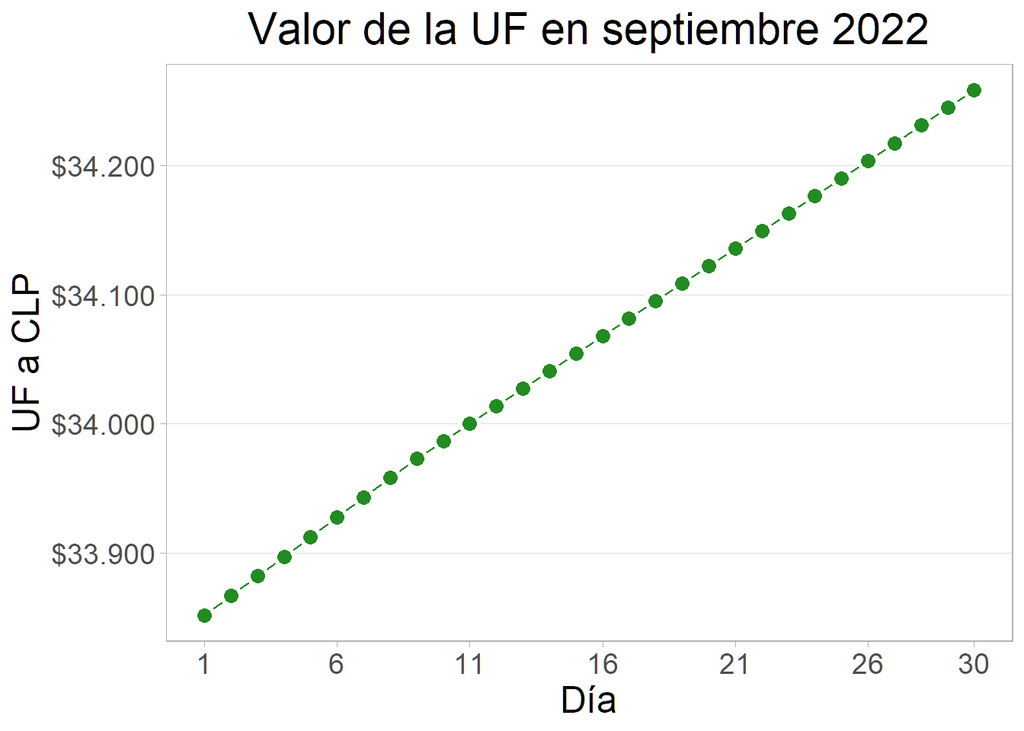